# events_locations_timeline_map

pmcdevitt

4 août 2017

#### Global Terrorism Database - https://www.start.umd.edu/gtd/

As a means to identify events clustering and geographic trends, we present the following analysis. The GT database provides the latitude and longitude location of each terrorist attack, along with the date on which it occurred. The database reports events from 1970 to 2015, in all, approximately 156,000 events. To understand the geographic changing nature of terrorism over this period, we determine the geographic center of all the events that occurred in each year. That is to say, for all of the terror events that occurred in 1970, and for each subsequent year, the geo-centroid of the all of the latitude and longitude coordinates was determined.

The result of this is depicted in Figure 1. We can observe that in 1970 the “center” of terrorist activity occurred at latitude, longitude (30.649873, -80.178993), which corresponds to a location in the North Altantic Ocean, approximately 40 miles east of Jacksonville, Florida. This means that of the 651 reported terrorist events reported in 1970, the geographic center was just off of the east coast of the United States. Furthermore, we can observe that during the subsequent 10 years of reported terrorist activity that the center of activity consistently moved eastward towards the European coast, then reverted back towards the Americas in the mid 1980s, and then made a steady progression, year by year eastward to arrive in the Persian Gulf about 20 miles NE of Qatar, at latitude, longitude (26.204019, 51.978154).

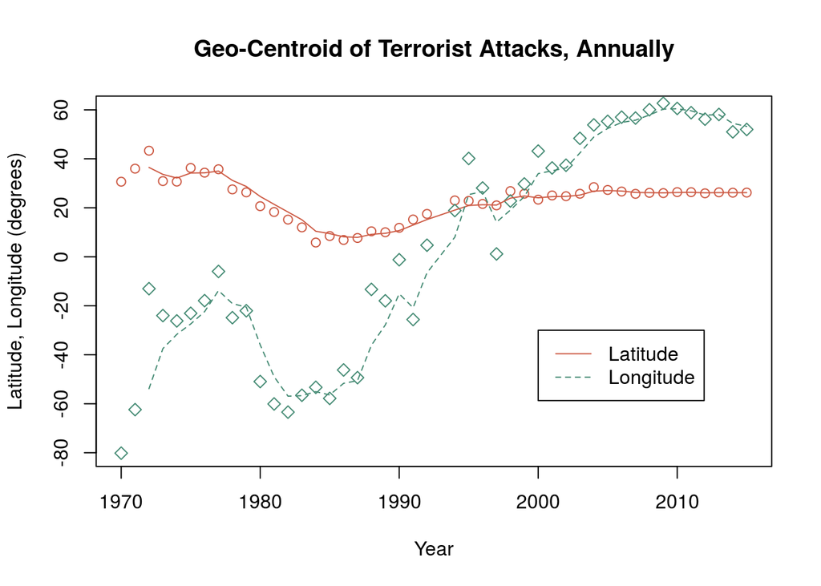

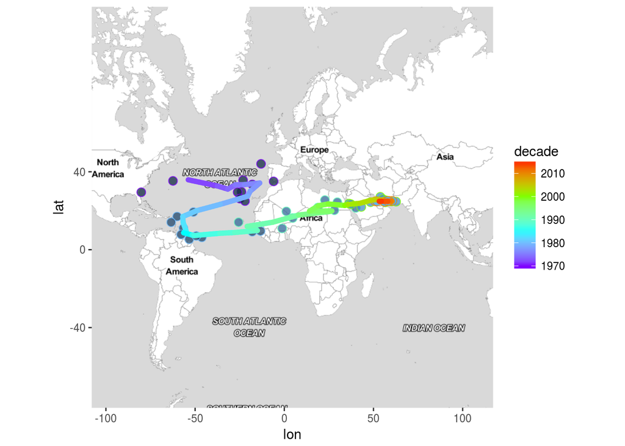

In this article, *The Bombings of America That We Forgot* (Bryan Burrough, Sep 20, 2016, http://time.com/4501670/bombings-of-america-burrough/) that sentiment is well expressed :

> Today, fifteen years after the 9/11 attacks, the explosion of a bomb remains a very big deal in this country. Detonating even the simplest pipe bomb, whether the work of some fringe militant group or a Unabomber-like kook, can draw the attentions of literally hundreds of journalists, photographers and law-enforcement personnel, not to mention rivet the rest of the country, as has been the case with the weekend’s casualty-free bombings in New York and New Jersey. It may be hard to recall now, but there was a time when most Americans were decidedly more blasé about bombing attacks. This was during the 1970s, when protest bombings in America were commonplace, especially in hard-hit cities like New York, Chicago and San Francisco. Nearly a dozen radical underground groups, dimly remembered outfits such as the Weather Underground, the New World Liberation Front and the Symbionese Liberation Army, set off hundreds of bombs during that tumultuous decade—so many, in fact, that many people all but accepted them as a part of daily life. As one woman sniffed to a New York Post reporter after an attack by a Puerto Rican independence group in 1977: “Oh, another bombing? Who is it this time?’” … While little remembered today, there was a time during the early 1970s when the U.S. government—the Nixon Administration—considered these groups a genuine threat to national security. Alarmed by a series of Weatherman attacks, Nixon told J. Edgar Hoover during a June 1970 Oval Office meeting that “revolutionary terror” represented the single greatest threat to American society. Hoover promised to do what he could, which wasn’t much.

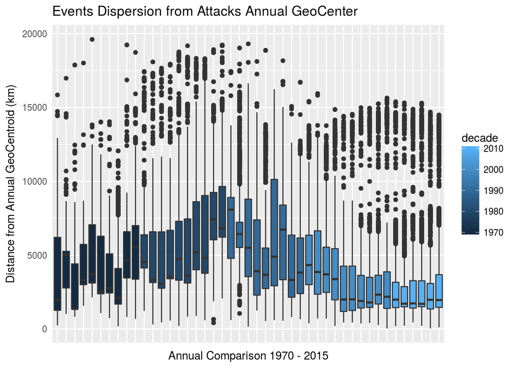

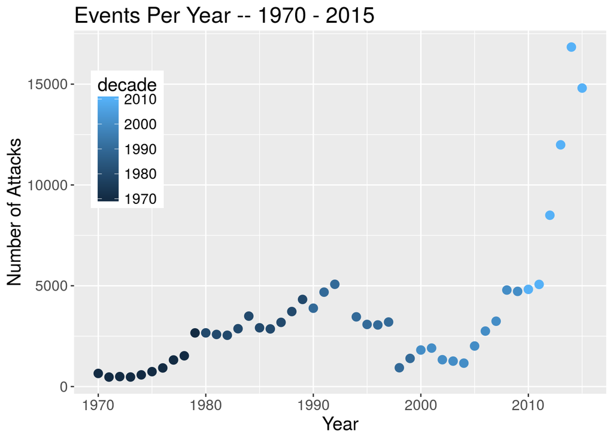

#### … -=-=-=-=-=-=-=-=-=-=-=-=-=-=-=-=-=-=-=-=-=-=-=-=-=-=-=-=-=-=-=-=-=-=-=-=-

#### … -=-=-=-=-=-=-=-=-=-=-=-=-=-=-=-=-=-=-=-=-=-=-=-=-=-=-=-=-=-=-=-=-=-=-=-=-